# Unspervised Clustering of Gene Expression Data

Isaac Kyeremateng, MD|MPH

2025-02-03

# Introduction

Given a set of gene expression data, we want to run an unsupervised clustering. This dataset consists of gene expression profiles across multiple samples. Each row represents a specific gene, identified by its unique gene_name, while each column (P1 through P1028) represents expression levels in different patient samples or experimental conditions.

## Workflow

1. **Determine Optimal Clusters (K)**: Use Mercator to generate a Scree plot and an Auer-Gervini plot to identify the best number of clusters (K) for the dataset.
2. **Evaluate Distance Metrics**: Perform hierarchical clustering using the identified K value and compare three distance measures (Euclidean, Manhattan, and Canberra) by computing silhouette width to determine the optimal approach.
3. **Visualize Clustering Results**: Apply UMAP and t-SNE to visualize the clustering, ensuring that data points are color-coded by Cluster ID for better interpretability.

# Load packages

We will load the required packages ‘Mercator’, ‘mclust’ and ‘readxl’

```r
suppressMessages(suppressWarnings(library(Mercator)))
suppressMessages(suppressWarnings(library(mclust)))
suppressMessages(suppressWarnings(library(readxl)))
```

# Import and check data

```r
df <- read_xlsx("C:\\Users\\fasci\\OneDrive\\Desktop\\BMI\\2. BMDS II\\BMIDS Homework 1.xlsx")
head(df)
```

```
## # A tibble: 6 × 1,029
##   gene_name     P1    P2     P3    P4     P5    P6    P7    P8     P9   P10
##   <chr>      <dbl> <dbl>  <dbl> <dbl>  <dbl> <dbl> <dbl> <dbl>  <dbl> <dbl>
## 1 AOC1        2.65  307.   1.97  14.2   2.54  145.  55.0  41.7   5.68  89.2
## 2 TMEM176A  273.    189.   1.59 507.  595.    283. 303.  161.  174.   300.
## 3 PDK4      690.    337. 124.   296.  447.    235.  37.3  26.3  53.0   19.8
## 4 SLC25A5   211.    311. 733.   117.  380.    355. 336.  177.  298.   344.
## 5 TNFRSF12A 124.    180.   3.78 123.   50.3   164. 182.   86.6  46.3   86.1
## 6 CD9        35.8   337. 427.   117.   93.9   366. 103.   44.7  75.4   51.8
## # ℹ 1,018 more variables: P11 <dbl>, P12 <dbl>, P13 <dbl>, P14 <dbl>,
## #   P15 <dbl>, P16 <dbl>, P17 <dbl>, P18 <dbl>, P19 <dbl>, P20 <dbl>,
## #   P21 <dbl>, P22 <dbl>, P23 <dbl>, P24 <dbl>, P25 <dbl>, P26 <dbl>,
## #   P27 <dbl>, P28 <dbl>, P29 <dbl>, P30 <dbl>, P31 <dbl>, P32 <dbl>,
## #   P33 <dbl>, P34 <dbl>, P35 <dbl>, P36 <dbl>, P37 <dbl>, P38 <dbl>,
## #   P39 <dbl>, P40 <dbl>, P41 <dbl>, P42 <dbl>, P43 <dbl>, P44 <dbl>,
## #   P45 <dbl>, P46 <dbl>, P47 <dbl>, P48 <dbl>, P49 <dbl>, P50 <dbl>, …
```

# Initial data analysis

We check the dimensions of the data as well as missing data

```r
dim(df)
```

```
## [1]  431 1029
```

```r
missing_data <- any (is.na(df))
missing_data
```

```
## [1] FALSE
```

From the above, we have no missing data.

# Average gene expression

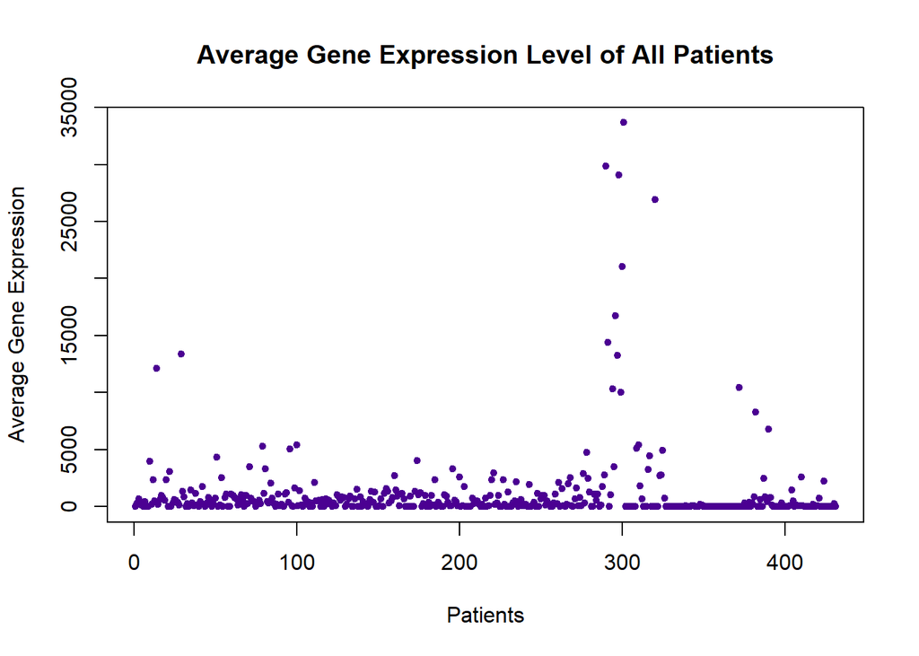

```r
df_copy <- df
df_num <- df_copy[,-1]
labdf <- as.data.frame(colMeans(df_num))
labdf$name <- rep("labnew", length(df_num))
colnames(df_num) <- c("avg","group")
plot(df_num$avg, main='Average Gene Expression Level of All Patients', xlab="Patients", ylab="Average Gene Expression", col="#4B0092", pch=20)
```

# Generating Binary Matrix

The **Mercator** package primarily operates on a BinaryMatrix S4 object, which serves as input for various functions and visualizations. While originally designed for binary data, BinaryMatrix can also handle integer and numeric values. Additionally, Mercator’s visualization tools support arbitrary distance matrices, enhancing its flexibility for data analysis.[Abrams and colleages]

```r
df_copy <- as.matrix(df_copy[,-1])
my.binmat <- BinaryMatrix(df_copy)
summary(my.binmat)
```

```
## An object of the 'BinaryMatrix' class, of size
## [1]  431 1028
## History:
## [1] "Newly created."
```

## Transpose the BinaryMatrix

```r
my.binmat <- t(my.binmat)
summary(my.binmat)
```

```
## An object of the 'BinaryMatrix' class, of size
## [1] 1028  431
## History:
## [1] "Newly created." "transposed"
```

## Remove Duplicates

```r
my.binmat <- removeDuplicates(my.binmat)
summary(my.binmat)
```

```
## An object of the 'BinaryMatrix' class, of size
## [1] 1028  431
## History:
## [1] "Newly created."      "transposed"          "Duplicates removed."
```

```r
length(my.binmat@info$notUsed)
```

```
## [1] 0
```

```r
head(my.binmat@info$notUsed)
```

```
## character(0)
```

```r
length(my.binmat@info$redundant)
```

```
## [1] 0
```

# Data Filtering with Thresher

```r
set.seed(21348)
my.binmat <- threshLGF(my.binmat, cutoff=0.3)
summary(my.binmat)
```

```
## An object of the 'BinaryMatrix' class, of size
## [1] 1028  417
## History:
## [1] "Newly created."      "transposed"          "Duplicates removed."
## [4] "Threshed."
```

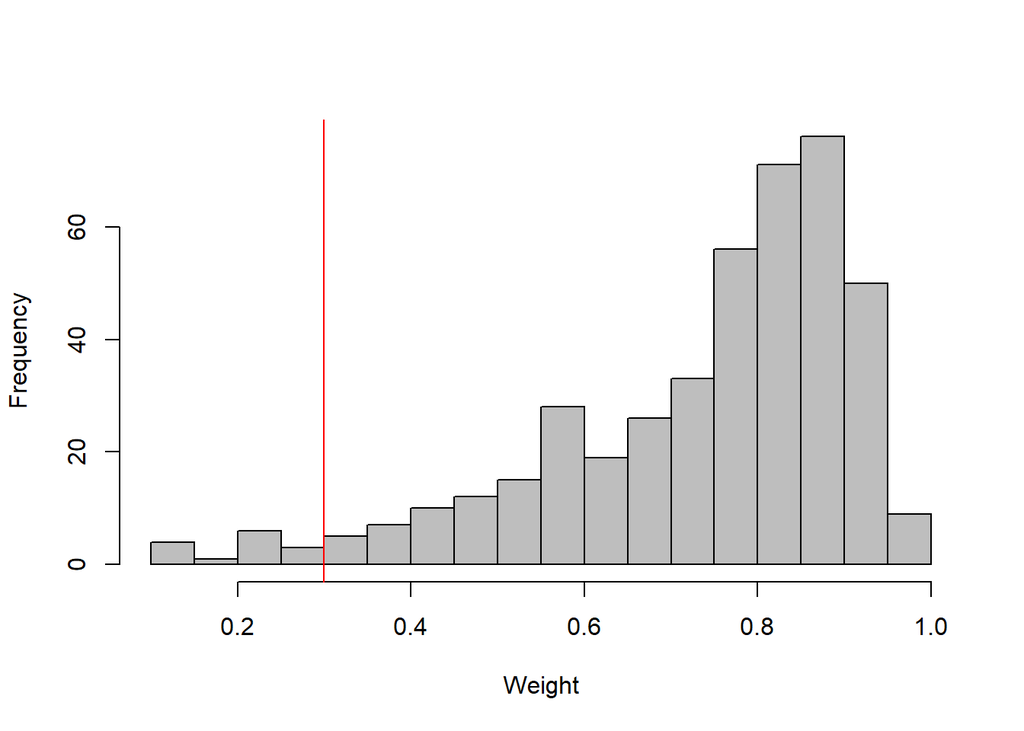

```r
Delta <- my.binmat@thresher@delta
hist(Delta, breaks=20, main="", xlab="Weight", col="gray")
abline(v=0.3, col='red')
```

```r
my.binmat@reaper@pcdim
```

```
## [1] 16
```

```r
my.binmat@reaper@nGroups
```

```
## [1] 33
```

#Auer-Gervini Plot

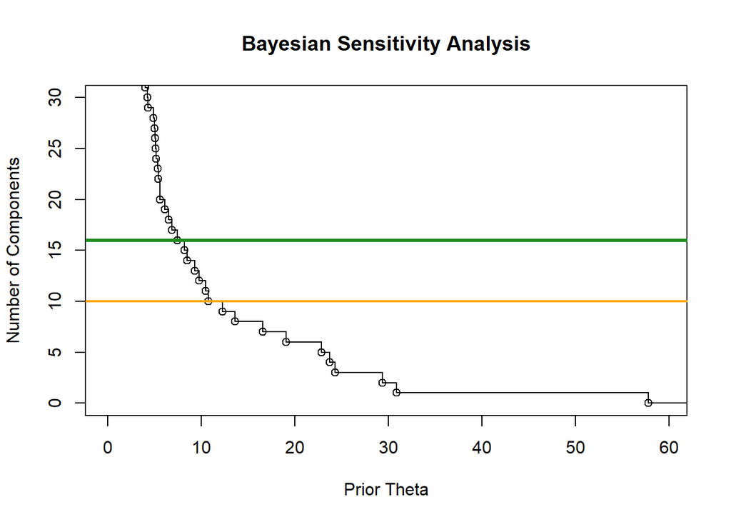

```r
plot(my.binmat@reaper@ag, ylim=c(0, 30))
abline(h=my.binmat@reaper@pcdim, col="forestgreen", lwd=3)
abline(h= 10, col="orange", lwd=2)
```

# Scree Plot

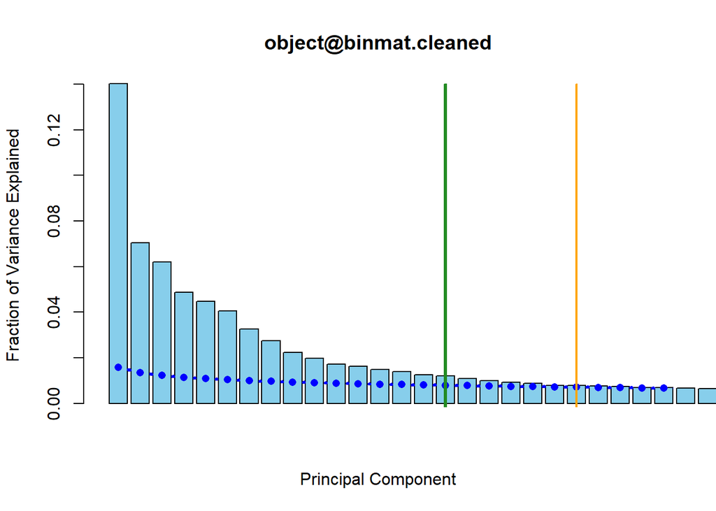

```r
pts <- screeplot(my.binmat@reaper, xlim=c(0,30))
abline(v=pts[my.binmat@reaper@pcdim], col="forestgreen", lwd=3)
abline(v=pts[22], col="orange", lwd=2)
```

# Hierarchical clustering

## Euclidean distance

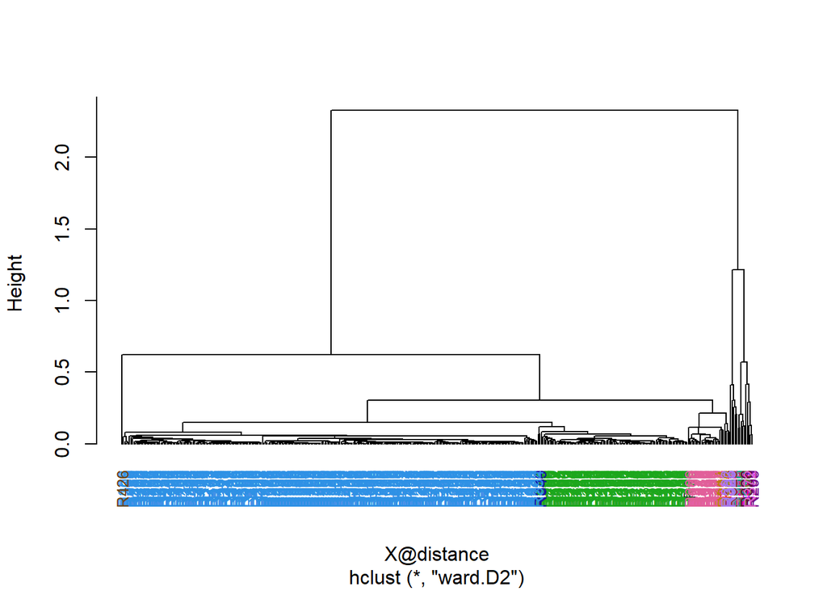

```r
euc.vis <- Mercator(my.binmat, "euclid", "hclust", 22)
plot(euc.vis, view = "hclust")
```

### Silhouette-Width Barplot

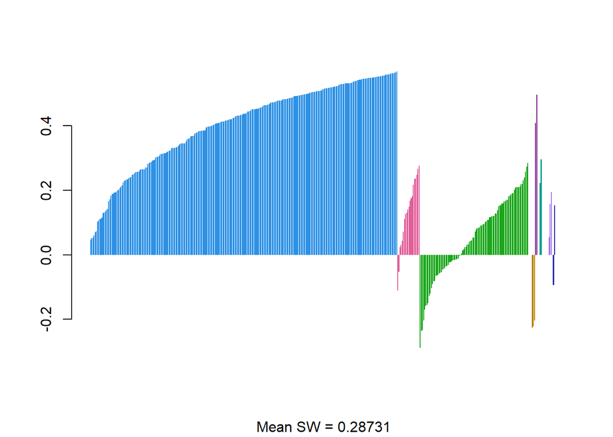

```r
barplot(euc.vis)
```

## Manhattan Distance

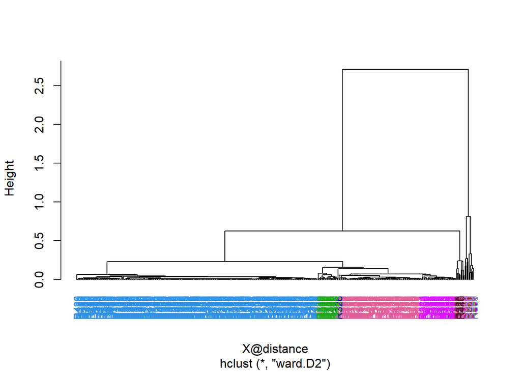

```r
mhatt.vis <- Mercator(my.binmat, "manhattan", "hclust", 22)
plot(mhatt.vis, view = "hclust")
```

### Silhouette-Width Barplot

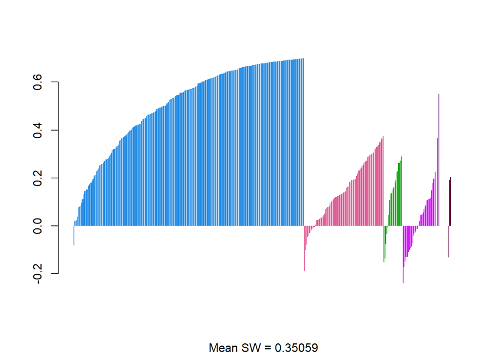

```r
barplot(mhatt.vis)
```

## Canberra Distance

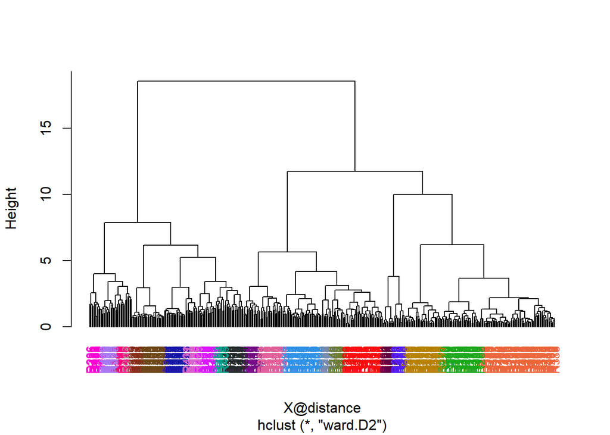

```r
canb.vis <- Mercator(my.binmat, "canberra", "hclust", 22)
plot(canb.vis, view = "hclust")
```

### Silhouette-Width Barplot

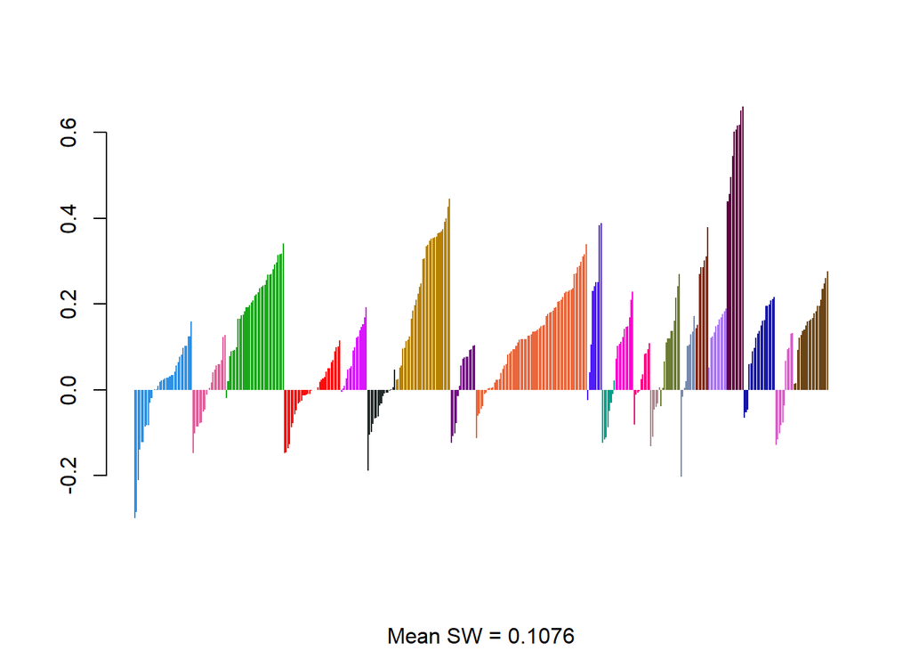

```r
barplot(canb.vis)
```